# Exploring the BRFSS data

## Setup

### Load packages

```r
library(ggplot2)
library(dplyr)
```

### Load data

```r
load("brfss2013.RData")
```

## Part 1: Data

The following Exploratory Data Analysis focuses on The Behavioral Risk Factor Surveillance System (BRFSS), which is a “cross sectional telephone survey that state health departments conduct monthly over landline telephones and cellular telephones with a standardized questionnaire” (CDC, 2013, p.3).

The questionnaire is comprised of an annual standard core, a biannual rotating core, optional modules and state-added questions. “The BRFSS uses two samples: one for landline telephone respondents and one for cellular telephone respondents” (CDC, 2013, P.6). For landline respondents a household sample is conducted, while cellular telephone respondents are weighted as single adult households. For Landline sampling Disproportionate stratified sampling (DSS) has been used since 2003. “DSS draws telephone numbers from two strata (lists) that are based on the presumed density of known telephone household numbers. In this design, telephone numbers are classified into strata that are either high density… [] or medium density to yield residential telephone numbers. Telephone numbers in the high density strarum are sampled at the highest rate” (CDC, 2013, p. 7). CDC argues that DSS sampling telephone numbers is more efficient than simple random sampling (SRS), while this may stand true, it implies that the study cannot be generalizable, however it might be useful for making causal conclusions.

As for the cellular telephone sample, the respondents are randomly selected “from a sampling frame of confirmed cellular area code and prefix combinations” (CDC, 2013, p. 8), this yields approximately 20% of total respondents. As for sample size. The BRFSS goal is to reach at least 4,000 interviews per state each year. According to the CDC “Factors influencing sample size include the cost involved in data collection for a larger sample and the states need for obtaining estimates for subpopulations within states” (2013, p. 7), this might mean that for some states with large and diverse population the results might not be representative of various minorities within the population as a whole, akin to other conditions and predicaments.

To avoid bias in sampling, the CDC makes use of weighting protocols which ensure that data are representative of the population “on several demographic characteristics including sex, age, race, education, marital status, home ownership, phone ownership and sub-state region. Because ranking considers each of the weighting variables separately, there is less likelihood that categories of age and/or race would collapse than under previous used with the new weighting methods. Ranking weighting incorporates the known characteristics of the population into the sample. If the sample is disproportionately females, ranking will adjust the responses of females in the sample to accurately represent the proportion of females in the population.” (2013, p. 8). This is due to an iterative process in which each demographic factor is introduced in a sequence. The sequence of factors may be multiple times before the sample is found to accurately represent the population on all factors under consideration (CDC, 2013).

## Part 2: Research questions

In the following report three questions are explored related to veterans in the United States of America and their use of medicare, the first question will explore the concentration of veterans in each state, the following question relates veterans from each state to their use of medicare; finally, the third question is about the relationship between cost of medicine and use of medicare.

- **Research question 1:** Which country has the highest concentration of vets?
- **Research question 2:** What is the relationship between veterans from each state and use of medicare?
- **Research question 3:** What is the relationship between having medicare and not being able to get Medicine due to cost as a veteran?

## Part 3: Exploratory data analysis

**Research question 1:**

Which country has the highest concentration of vets?

```r
### filters out information from veterans
vets <- brfss2013 %>%
     filter(veteran3 == "Yes")
### creates a numerical list of veterans by state
vets_state <- brfss2013 %>%
     group_by(X_state) %>%
     summarise(veteran3 = n())
### cleans up two extra rows
vets_state <- subset(vets_state, veteran3 > 2)
### shows it in descending order
vets_state %>%
  mutate(percentage = veteran3 / sum(veteran3)) %>%
  arrange(desc(veteran3))
```

```
## # A tibble: 53 × 3
##    X_state       veteran3 percentage
##    <fct>            <int>      <dbl>
##  1 Florida          33668     0.0685
##  2 Kansas           23282     0.0473
##  3 Nebraska         17139     0.0349
##  4 Massachusetts    15071     0.0306
##  5 Minnesota        14340     0.0292
##  6 New Jersey       13776     0.0280
##  7 Colorado         13649     0.0278
##  8 Maryland         13011     0.0265
##  9 Utah             12769     0.0260
## 10 Michigan         12761     0.0259
## # ℹ 43 more rows
```

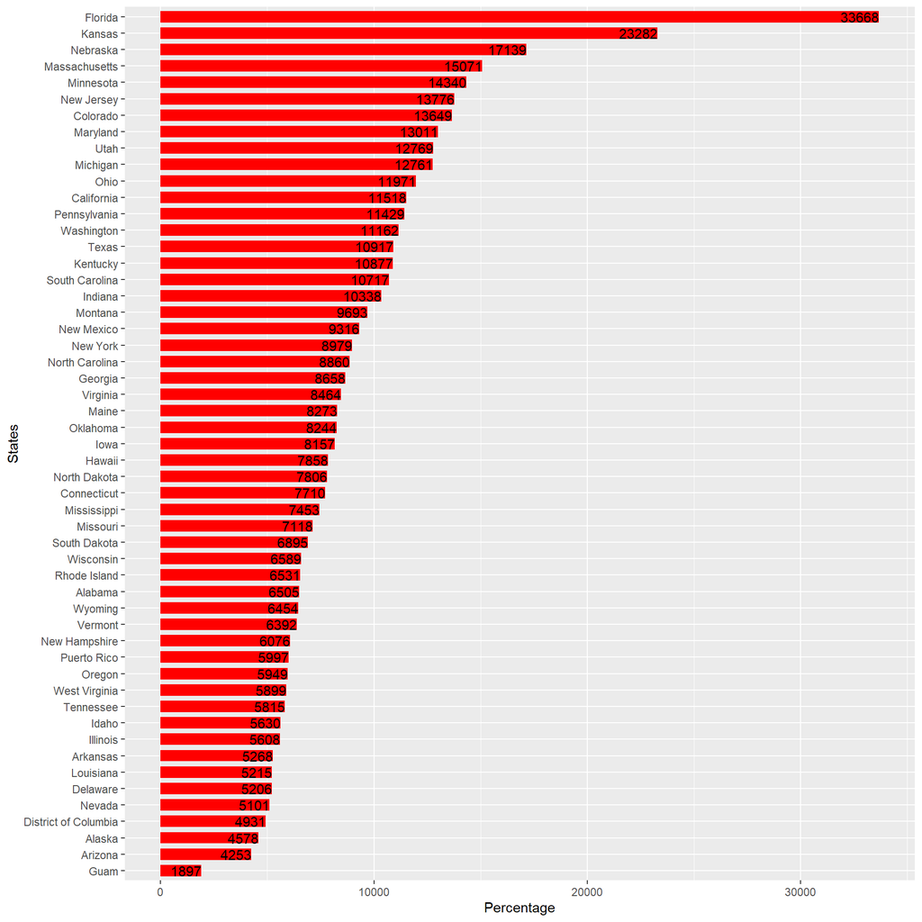

```r
### Creates a plot of concentration
ggplot(vets_state,aes(x = reorder(X_state, veteran3), y= veteran3)) +
  geom_bar(stat="identity",fill="Red", width = .7) +
  geom_text(aes(label = veteran3), hjust = 1) +
  coord_flip() +
  ylab("Percentage") + xlab("States")
```

**Research question 2:**

What is the relationship between veterans from each state and use of medicare?

Across the survey, around 62% of veterans have medicare while the rest claim not to have, there exist a large number of veterans to which this question does not apply, as it will be shown further.

```r
### Proportion table of total veterans with or without medicare
vets_state_medicare <- vets %>%
      select(X_state, medicare)

table(vets_state_medicare$medicare)
```

```
##
##   Yes    No
## 25328 15269
```

```r
prop.table(table(vets_state_medicare$medicare))
```

```
##
##       Yes        No
## 0.6238885 0.3761115
```

In the following graphic, the proportions of vets with, without and NA medicare are shown, the decision to include the NA responses is because there are other health insurance coverage options that are not medicare, but those are not the focus of the present research.

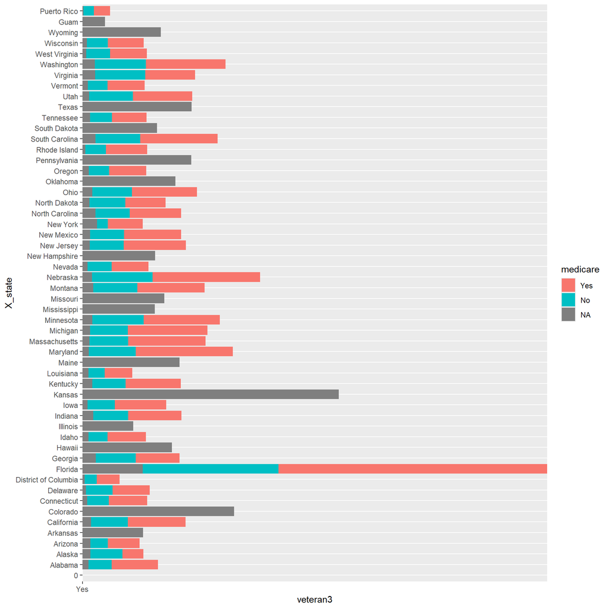

```r
### bar plots the veterans from each state and if they have medicare
ggplot(vets, aes(fill = medicare, y = veteran3, x= X_state)) +
     geom_bar(position = "stack", stat = "identity") +
     coord_flip()
```

```r
### Summary of veterans from each state that have medicare
vets_state_medicare %>%
    group_by(X_state) %>%
    select(X_state, medicare) %>%
    table()
```

```
##                       medicare
## X_state                 Yes   No
##   0                       0    0
##   Alabama               543  273
##   Alaska                247  378
##   Arizona               371  208
##   Arkansas                0    0
##   California            679  435
##   Colorado                0    0
##   Connecticut           452  253
##   Delaware              435  317
##   District of Columbia  269  145
##   Florida              3165 1599
##   Georgia               514  472
##   Hawaii                  0    0
##   Idaho                 452  227
##   Illinois                0    0
##   Indiana               627  414
##   Iowa                  606  323
##   Kansas                  0    0
##   Kentucky              651  391
##   Louisiana             325  190
##   Maine                   0    0
##   Maryland             1143  551
##   Massachusetts         912  456
##   Michigan              936  446
##   Minnesota             895  604
##   Mississippi             0    0
##   Missouri                0    0
##   Montana               792  519
##   Nebraska             1266  717
##   Nevada                433  284
##   New Hampshire           0    0
##   New Jersey            731  398
##   New Mexico            673  401
##   New York              412  125
##   North Carolina        604  405
##   North Dakota          475  421
##   Ohio                  765  467
##   Oklahoma                0    0
##   Oregon                438  237
##   Pennsylvania            0    0
##   Rhode Island          486  243
##   South Carolina        911  529
##   South Dakota            0    0
##   Tennessee             408  257
##   Texas                   0    0
##   Utah                  700  515
##   Vermont               437  233
##   Virginia              588  590
##   Washington            938  600
##   West Virginia         436  277
##   Wisconsin             424  245
##   Wyoming                 0    0
##   Guam                    0    0
##   Puerto Rico           189  124
##   80                      0    0
```

Something to note are the states with a grey bar, this means that no veteran surveyed found a “Yes” and “No” applicable to their situation, these states are, Arkansas, Colorado, Hawaii, Illinois, Kansas, Maine, Mississippi, Missouri, New Hampshire, Oklahoma, Pennsylvania, South Dakota, Texas, Wyoming and Guam (in no particular order). The reason of it is unknown to the scope of this research but further investigation is required.

**Research question 3:** What is the relationship between having medicare and not being able to get Medicine due to cost as a veteran?

```r
###Table of medicare and medcost
vets %>%
     group_by(medicare) %>%
     select(medicare, medcost) %>%
     table()
```

```
##         medcost
## medicare   Yes    No
##      Yes  1069 24202
##      No   1100 14151
```

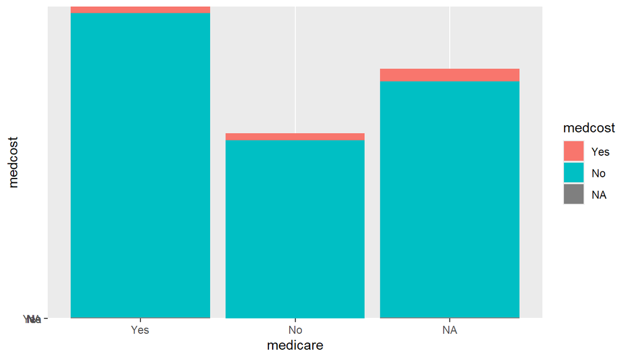

```r
### Stacked barplot medicare and medcost
ggplot(vets, aes(fill = medcost, y = medcost, x=medicare)) +
      geom_bar(position = "stack", stat = "identity")
```

This indicates that the majority of veterans can afford most forms of treatment, however it is important to asses the situation of the veterans that have not been able to afford treatment, this could be the result of multiple factors like, cost of treatment due to severity of medical condition, issues with the operation and coverage of health insurance and the lack of opportunity to afford health insurance, a focused study of the veterans that cannot afford the cost of medicine should be conducted.

## Part 4: Conclusions

The present Exploratory Data Analysis which wrangles with a data set from the BRFSS conducted in 2013 focused on veterans across the United States of America and focused on 3 key questions:

- Which country has the highest concentration of vets?
- What is the relationship between veterans from each state and use of medicare?
- What is the relationship between having medicare and not being able to get Medicine due to cost as a veteran?

The number of veterans that responded to having medicare are significantly lower than the number of total veterans counted, the reasons are unknown and out of the scope of the present research, throughout this Exploratory Data Analysis a couple of questions have been raised pertaining healthcare accessibility for veterans, I encourage the researchers that read this report to continue with the analysis.